# Summary

## Terms

### `Trader Initiated Event` (TIE)

`Trader Initiated Event` refers to observed events that will typically happen when it is instructed by trader to do so; Typical examples are, modifications, deletions, and creation of order.

### `Fast Order`s

`Fast orders` refer to orders whose's time between `TIE` is small, that it can only happen with automated system, i.e. if order is created and deleted 6 micro seconds later, this order has small TIE.

### `Slow Order`s

`Slow order` refers to orders whose's time between `TIE` is not small, that it can happen without automated system, i.e. if order is created and deleted 30 seconds later, this order has large TIE.

## Findings

1. Slow orders are less active on night session
2. Fast orders are more reactive to changes in market volatitlity
3. Orders with high modify count (e.g. market maker's order) is less active on night session
1. Product Overview: Overview of products
2. Executions: Re-creation of tick-by-tick data worked
3. Plotout maker order activity
   - 3.1 Number of `observed maker order *creation*` of orders whose smallest time between `trader initiated event` is less than 1 second
   - 3.2 Number of `observed maker order *modification*` of orders whose smallest time between `trader initiated event` is less than 1 second
   - 3.3 Number of `observed maker order *creation*` of orders whose smallest time between `trader initiated event` is greather than 30 seconds
   - 3.4 Number of `observed maker order *modification*` of orders who were *modified* more than *5 times* durting the trading session.
   - 3.5 Number of `observed maker order *creation*` of orders who were `deleted` before the end of trading session.

```python
import polars as pl
import os

product_info_df=pl.scan_ndjson("../ndjson/product-info*").collect()
```

# 1. Product Overview

1. How many products do we have, per category?
2. What kind of future contracts do we have?

```python
product_info_df.group_by(pl.col("symbol").str.split("_").list.get(1)).count().sort("count", descending=True)
```

shape: (232, 2)

| symbol str | count u32 |
| --- | --- |
| "NK225" | 4436 |
| "JGBL" | 186 |
| "8035" | 154 |
| "6954" | 142 |
| "7203" | 124 |
| "9983" | 124 |
| "1330" | 118 |
| "6367" | 114 |
| "6762" | 114 |
| "1321" | 110 |
| "1320" | 110 |
| "1309" | 106 |
| … | … |
| "9502" | 52 |
| "8972" | 52 |
| "1328" | 50 |
| "8410" | 50 |
| "4631" | 50 |
| "9504" | 50 |
| "1615" | 50 |
| "1540" | 48 |
| "NK225M" | 23 |
| "JGBM" | 6 |
| "JGBSL" | 6 |
| "JGBLM" | 6 |

```python
product_info_df.filter(pl.col("financial_product") == "Future").sort(pl.col("expiration_date"))
```

shape: (28, 12)

| timestamp str | expiration_date i64 | financial_product str | long_name str | number_of_decimal_in_price i64 | number_of_decimals_in_strike_price i64 | number_of_legs i64 | order_book_id i64 | put_or_call str | strike_price i64 | symbol str | underlying_order_book_id i64 |
| --- | --- | --- | --- | --- | --- | --- | --- | --- | --- | --- | --- |
| "2021-02-28T21:… | 20210312 | "Future" | "166030019" | 4 | 0 | 0 | 459262 | "Combo" | 0 | "FUT_NK225M_210… | 510 |
| "2021-02-28T21:… | 20210315 | "Future" | "166030007" | 4 | 0 | 0 | 262434 | "Combo" | 0 | "FUT_JGBLM_2103… | 290 |
| "2021-02-28T21:… | 20210322 | "Future" | "166030001" | 4 | 0 | 0 | 14811406 | "Combo" | 0 | "FUT_JGBL_2103" | 270 |
| "2021-02-28T21:… | 20210322 | "Future" | "166030004" | 4 | 0 | 0 | 262404 | "Combo" | 0 | "FUT_JGBM_2103" | 260 |
| "2021-02-28T21:… | 20210322 | "Future" | "166030002" | 4 | 0 | 0 | 262424 | "Combo" | 0 | "FUT_JGBSL_2103… | 280 |
| "2021-02-28T21:… | 20210409 | "Future" | "166040019" | 4 | 0 | 0 | 1180158 | "Combo" | 0 | "FUT_NK225M_210… | 510 |
| "2021-02-28T21:… | 20210514 | "Future" | "166050019" | 4 | 0 | 0 | 1049086 | "Combo" | 0 | "FUT_NK225M_210… | 510 |
| "2021-02-28T21:… | 20210611 | "Future" | "166060019" | 4 | 0 | 0 | 1114622 | "Combo" | 0 | "FUT_NK225M_210… | 510 |
| "2021-02-28T21:… | 20210614 | "Future" | "166060007" | 4 | 0 | 0 | 393506 | "Combo" | 0 | "FUT_JGBLM_2106… | 290 |
| "2021-02-28T21:… | 20210621 | "Future" | "166060001" | 4 | 0 | 0 | 14680334 | "Combo" | 0 | "FUT_JGBL_2106" | 270 |
| "2021-02-28T21:… | 20210621 | "Future" | "166060004" | 4 | 0 | 0 | 393476 | "Combo" | 0 | "FUT_JGBM_2106" | 260 |
| "2021-02-28T21:… | 20210621 | "Future" | "166060002" | 4 | 0 | 0 | 393496 | "Combo" | 0 | "FUT_JGBSL_2106… | 280 |
| … | … | … | … | … | … | … | … | … | … | … | … |
| "2021-02-28T21:… | 20210921 | "Future" | "166090004" | 4 | 0 | 0 | 131332 | "Combo" | 0 | "FUT_JGBM_2109" | 260 |
| "2021-02-28T21:… | 20210921 | "Future" | "166090002" | 4 | 0 | 0 | 131352 | "Combo" | 0 | "FUT_JGBSL_2109… | 280 |
| "2021-02-28T21:… | 20211210 | "Future" | "166120019" | 4 | 0 | 0 | 328190 | "Combo" | 0 | "FUT_NK225M_211… | 510 |
| "2021-02-28T21:… | 20220311 | "Future" | "167030019" | 4 | 0 | 0 | 131582 | "Combo" | 0 | "FUT_NK225M_220… | 510 |
| "2021-02-28T21:… | 20220610 | "Future" | "167060019" | 4 | 0 | 0 | 393726 | "Combo" | 0 | "FUT_NK225M_220… | 510 |
| "2021-02-28T21:… | 20221209 | "Future" | "167120019" | 4 | 0 | 0 | 524798 | "Combo" | 0 | "FUT_NK225M_221… | 510 |
| "2021-02-28T21:… | 20230609 | "Future" | "168060019" | 4 | 0 | 0 | 655870 | "Combo" | 0 | "FUT_NK225M_230… | 510 |
| "2021-02-28T21:… | 20231208 | "Future" | "168120019" | 4 | 0 | 0 | 721406 | "Combo" | 0 | "FUT_NK225M_231… | 510 |
| "2021-02-28T21:… | 20240614 | "Future" | "169060019" | 4 | 0 | 0 | 786942 | "Combo" | 0 | "FUT_NK225M_240… | 510 |
| "2021-02-28T21:… | 20241213 | "Future" | "169120019" | 4 | 0 | 0 | 852478 | "Combo" | 0 | "FUT_NK225M_241… | 510 |
| "2021-02-28T21:… | 20250613 | "Future" | "160060019" | 4 | 0 | 0 | 262654 | "Combo" | 0 | "FUT_NK225M_250… | 510 |
| "2021-02-28T21:… | 20251212 | "Future" | "160120019" | 4 | 0 | 0 | 983550 | "Combo" | 0 | "FUT_NK225M_251… | 510 |

# 2. Executions

Re-create tick-by-tick data

```python
import path

def cell():
    stack = []
    for i in os.listdir("../ndjson/"):
        if "exec_price" in i and "459262" in i:
            fpath = f"../ndjson/{i}"
            if path.Path(fpath).size > 0:
                stack.append(pl.scan_ndjson(fpath).collect())

    for i in stack[1:]:
        stack[0] = stack[0].vstack(i)

    return stack[0].with_columns(pl.col("timestamp").cast(pl.Datetime), pl.col("maker_side").cast(pl.Categorical)).select(pl.exclude("maker_id"))

e_df: pl.DataFrame = cell()
e_df
```

shape: (255_022, 4)

| timestamp datetime[μs] | trade_price i64 | maker_side cat | is_ctag bool |
| --- | --- | --- | --- |
| 2021-02-28 23:45:01.052824 | 296150000 | "Buy" | true |
| 2021-02-28 23:45:01.052824 | 296150000 | "Sell" | true |
| 2021-02-28 23:45:01.052824 | 296150000 | "Buy" | true |
| 2021-02-28 23:45:01.052824 | 296150000 | "Buy" | true |
| 2021-02-28 23:45:01.052824 | 296150000 | "Sell" | true |
| 2021-02-28 23:45:01.052824 | 296150000 | "Sell" | true |
| 2021-02-28 23:45:01.052824 | 296150000 | "Sell" | true |
| 2021-02-28 23:45:01.052824 | 296150000 | "Sell" | true |
| 2021-02-28 23:45:01.052824 | 296150000 | "Buy" | true |
| 2021-02-28 23:45:01.052824 | 296150000 | "Sell" | true |
| 2021-02-28 23:45:01.052824 | 296150000 | "Sell" | true |
| 2021-02-28 23:45:01.052824 | 296150000 | "Sell" | true |
| … | … | … | … |
| 2021-03-01 20:30:01.019817 | 298600000 | "Buy" | true |
| 2021-03-01 20:30:01.019817 | 298600000 | "Buy" | true |
| 2021-03-01 20:30:01.019817 | 298600000 | "Sell" | true |
| 2021-03-01 20:30:01.019817 | 298600000 | "Sell" | true |
| 2021-03-01 20:30:01.019817 | 298600000 | "Sell" | true |
| 2021-03-01 20:30:01.019817 | 298600000 | "Sell" | true |
| 2021-03-01 20:30:01.019817 | 298600000 | "Sell" | true |
| 2021-03-01 20:30:01.019817 | 298600000 | "Sell" | true |
| 2021-03-01 20:30:01.019817 | 298600000 | "Sell" | true |
| 2021-03-01 20:30:01.019817 | 298600000 | "Sell" | true |
| 2021-03-01 20:30:01.019817 | 298600000 | "Sell" | true |
| 2021-03-01 20:30:01.019817 | 298600000 | "Sell" | true |

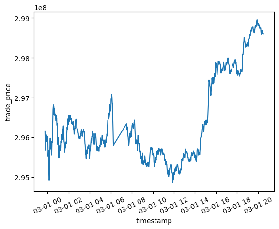

```python
import seaborn as sns
def cell():
    _df=e_df.group_by(pl.col("timestamp").dt.truncate("1m")).agg([pl.col("trade_price").mean()])
    ax = sns.lineplot(y=_df["trade_price"], x=_df["timestamp"])
    for i in ax.get_xticklabels():
        i.set_rotation(25)

cell()
```

# 3. Plotout maker order activity

setting up necessary data

```python
import path

def cell():
    func = lambda x: (pl.col("financial_product") == x)&pl.col("symbol").str.contains("NK225")

    order_book_id_series_func = lambda x: product_info_df.filter(func(x)).select(pl.col("order_book_id").cast(pl.Utf8))["order_book_id"]
    order_book_id_series_func("Future")
    order_book_id_series = order_book_id_series_func("Option")
    stack = []
    for i in os.listdir("../ndjson/"):
        id = i.split("Some(")[1].split(")")[0]
        if "order-" in i and id in order_book_id_series:
            fpath = f"../ndjson/{i}"
            if path.Path(fpath).size > 0:
                stack.append(pl.scan_ndjson(fpath).collect())

    for i in stack[1:]:
        stack[0] = stack[0].vstack(i)

    df2 = stack[0]
    tscol = pl.col("timestamp").cast(pl.Datetime)
    tocat  = pl.col(pl.Utf8).cast(pl.Categorical)
    idcol = pl.col("order_id").cast(pl.Struct({"side": pl.Categorical, "order_id": pl.UInt64, "order_book_id": pl.Int64}))
    return df2.with_columns([idcol, tscol]).with_columns(tocat).with_columns(idcol)
df2: pl.DataFrame =cell()
```

```python
def cell():
    colts=pl.col("timestamp").sort().diff()
    iter = [
        pl.col("timestamp").min().alias("created_on"),
        colts.min().alias("min"),
        colts.max().alias('max'),
        colts.count().alias("count"),
        pl.col("event").filter(pl.col("event") == "Modify").count().alias("modify"),
    ]
    df = pl.DataFrame()
    for i in iter:
        _df=df2.lazy().group_by(pl.col("order_id")).agg([i])
        func = lambda s: pl.col("order_id").struct.field(s)
        schema = [func("order_id"), func("order_book_id"), func("side")]
        if df.height:
            _df2=_df.sort(schema).select(pl.exclude("order_id")).collect()
            df=df.sort(schema).hstack(_df2, in_place =True)
        else:
            df = _df.sort(schema).collect()

    return df

df3=cell()
df3
```

shape: (9_323_874, 6)

| order_id struct[3] | created_on datetime[μs] | min duration[μs] | max duration[μs] | count u32 | modify u32 |
| --- | --- | --- | --- | --- | --- |
| {"Buy",7191680986344451283,141099508} | 2021-02-28 21:07:50.931282 | null | null | 1 | 0 |
| {"Buy",7191680986344452353,141033972} | 2021-02-28 21:07:50.931282 | null | null | 1 | 0 |
| {"Buy",7191680986344462060,140837364} | 2021-02-28 21:07:50.931282 | null | null | 1 | 0 |
| {"Buy",7191680986344469723,140771828} | 2021-02-28 21:07:50.931282 | null | null | 1 | 0 |
| {"Buy",7191680986344473992,140706292} | 2021-02-28 21:07:50.931282 | null | null | 1 | 0 |
| {"Buy",7191680986344478517,140640756} | 2021-02-28 21:07:50.931282 | null | null | 1 | 0 |
| {"Buy",7191680986344482094,140575220} | 2021-02-28 21:07:50.931282 | null | null | 1 | 0 |
| {"Buy",7191680986344483411,140509684} | 2021-02-28 21:07:50.931282 | null | null | 1 | 0 |
| {"Buy",7191680986344488974,140444148} | 2021-02-28 21:07:50.931282 | null | null | 1 | 0 |
| {"Buy",7191680986344491275,140378612} | 2021-02-28 21:07:50.931282 | null | null | 1 | 0 |
| {"Buy",7191680986344495193,140313076} | 2021-02-28 21:07:50.931282 | null | null | 1 | 0 |
| {"Buy",7191680986344496787,140247540} | 2021-02-28 21:07:50.931282 | null | null | 1 | 0 |
| … | … | … | … | … | … |
| {"Buy",7396717914718470994,104137204} | 2021-03-01 20:29:59.962684 | null | null | 1 | 0 |
| {"Buy",7396717914718470995,239469044} | 2021-03-01 20:29:59.962813 | null | null | 1 | 0 |
| {"Sell",7396717914718470996,52888052} | 2021-03-01 20:29:59.962854 | 101461µs | 101461µs | 2 | 0 |
| {"Sell",7396717914718470997,158794228} | 2021-03-01 20:29:59.962908 | null | null | 1 | 0 |
| {"Sell",7396717914718470998,231145972} | 2021-03-01 20:29:59.962954 | null | null | 1 | 0 |
| {"Buy",7396717914718471003,21758452} | 2021-03-01 20:30:00.254932 | 10m 758443µs | 10m 758443µs | 2 | 0 |
| {"Buy",7396717914718471004,33817076} | 2021-03-01 20:30:00.254968 | 754165µs | 754165µs | 2 | 0 |
| {"Buy",7396717914718471005,297337332} | 2021-03-01 20:30:00.255009 | 756683µs | 756683µs | 2 | 0 |
| {"Sell",7396717914718471006,98238964} | 2021-03-01 20:30:00.255046 | 10m 758329µs | 10m 758329µs | 2 | 0 |
| {"Buy",7396717914718471007,258605556} | 2021-03-01 20:30:00.255277 | 753782µs | 753782µs | 2 | 0 |
| {"Sell",7396717914718471016,54723060} | 2021-03-01 20:30:00.992569 | null | null | 1 | 0 |
| {"Sell",7396717914718471017,33751540} | 2021-03-01 20:30:00.992613 | null | null | 1 | 0 |

```python
df2_2=df2.filter(pl.col("event") == "Modify").group_by(pl.col("order_id")).count().lazy().collect()
df2_2
```

shape: (1_052_329, 2)

| order_id struct[3] | count u32 |
| --- | --- |
| {"Buy",7395532366336512559,100205044} | 1 |
| {"Buy",7395532366337068368,100205044} | 1 |
| {"Sell",7396717914678627295,100205044} | 1 |
| {"Buy",7396717914678726638,100205044} | 3 |
| {"Buy",7396717914678910338,100205044} | 2 |
| {"Buy",7396717914678923311,100205044} | 6 |
| {"Sell",7396717914678928159,100205044} | 1 |
| {"Sell",7396717914678941974,100205044} | 1 |
| {"Sell",7396717914679005129,100205044} | 1 |
| {"Sell",7396717914679024960,100205044} | 1 |
| {"Buy",7396717914679056093,100205044} | 2 |
| {"Sell",7396717914678993206,100205044} | 1 |
| … | … |
| {"Buy",7396717914717709373,99156468} | 1 |
| {"Sell",7396717914717755982,99156468} | 1 |
| {"Sell",7396717914717763382,99156468} | 1 |
| {"Buy",7396717914717911079,99156468} | 1 |
| {"Sell",7396717914717982228,99156468} | 1 |
| {"Sell",7396717914718039154,99156468} | 2 |
| {"Sell",7396717914717784766,99156468} | 1 |
| {"Buy",7396717914688822957,99549684} | 1 |
| {"Sell",7396717914691355904,99549684} | 1 |
| {"Buy",7396717914682502279,99746292} | 1 |
| {"Sell",7396717914682809329,99746292} | 1 |
| {"Buy",7396717914685554583,99746292} | 1 |

```python
func = lambda s: pl.col("order_id").struct.field(s)
schema = [func("order_id"), func("order_book_id"), func("side")]
df2_2=df2.filter(pl.col("event") == "Modify").group_by(pl.col("order_id")).count().with_columns(pl.col("count").alias("modify_count"))
df2_2=df2.with_columns(schema).join(df2_2.with_columns(schema), on="order_id", how="anti")
df2_2
```

shape: (16_519_928, 5)

| timestamp datetime[μs] | order_id u64 | event cat | order_book_id i64 | side cat |
| --- | --- | --- | --- | --- |
| 2021-02-28 21:07:50.931282 | 7387220058386959605 | "Created" | 100205044 | "Buy" |
| 2021-02-28 21:07:50.931282 | 7372574288600056251 | "Created" | 100205044 | "Buy" |
| 2021-02-28 21:07:50.931282 | 7372574288600056565 | "Created" | 100205044 | "Buy" |
| 2021-02-28 21:07:50.931282 | 7387220058386959281 | "Created" | 100205044 | "Buy" |
| 2021-02-28 21:07:50.931282 | 7372574288600056040 | "Created" | 100205044 | "Buy" |
| 2021-02-28 23:00:16.536242 | 7396717914678609207 | "Created" | 100205044 | "Buy" |
| 2021-02-28 23:10:15.375893 | 7396717914678614297 | "Created" | 100205044 | "Buy" |
| 2021-02-28 23:22:30.802078 | 7396717914678624033 | "Created" | 100205044 | "Sell" |
| 2021-02-28 23:30:02.333860 | 7396717914678627294 | "Created" | 100205044 | "Sell" |
| 2021-02-28 23:32:03.237693 | 7396717914678628551 | "Created" | 100205044 | "Sell" |
| 2021-02-28 23:33:05.127995 | 7396717914678629083 | "Created" | 100205044 | "Sell" |
| 2021-02-28 23:42:04.905666 | 7396717914678624033 | "Deleted" | 100205044 | "Sell" |
| … | … | … | … | … |
| 2021-03-01 16:44:13.338961 | 7396717914716721227 | "Deleted" | 99746292 | "Buy" |
| 2021-03-01 16:44:13.603282 | 7396717914716837902 | "Created" | 99746292 | "Buy" |
| 2021-03-01 16:47:42.715536 | 7396717914716876335 | "Created" | 99746292 | "Buy" |
| 2021-03-01 16:47:42.715536 | 7396717914716837902 | "Deleted" | 99746292 | "Buy" |
| 2021-03-01 16:48:52.094288 | 7396717914716885862 | "Created" | 99746292 | "Sell" |
| 2021-03-01 16:48:52.094288 | 7396717914716824026 | "Deleted" | 99746292 | "Sell" |
| 2021-03-01 16:50:22.964059 | 7396717914716906724 | "Created" | 99746292 | "Buy" |
| 2021-03-01 16:50:22.964059 | 7396717914716876335 | "Deleted" | 99746292 | "Buy" |
| 2021-03-01 16:52:04.958021 | 7396717914716885862 | "Deleted" | 99746292 | "Sell" |
| 2021-03-01 16:52:04.958021 | 7396717914716925688 | "Created" | 99746292 | "Sell" |
| 2021-03-01 16:54:08.529018 | 7396717914716906724 | "Deleted" | 99746292 | "Buy" |
| 2021-03-01 16:54:08.529018 | 7396717914716925688 | "Deleted" | 99746292 | "Sell" |

```python
func = lambda s: pl.col("order_id").struct.field(s)
schema = [func("order_id"), func("order_book_id"), func("side")]

m_df2_2=df2.filter(pl.col("event") == "Modify").group_by(pl.col("order_id")).count().with_columns(pl.col("count").alias("modify_count"))
d_df2_2=df2.filter(pl.col("event") == "Deleted").group_by(pl.col("order_id")).count().filter(pl.col("count") > 0).with_columns(pl.col("count").cast(pl.Boolean).alias("is_deleted"))
_df=m_df2_2.join(d_df2_2, on=schema, how="inner").select(pl.exclude(["count_right", "count"]))
```

```python
_df.group_by(["order_id",	"order_book_id", "side"]).count()
```

shape: (1_045_496, 4)

| order_id u64 | order_book_id i64 | side cat | count u32 |
| --- | --- | --- | --- |
| 7396717914679731549 | 100205044 | "Sell" | 1 |
| 7396717914681990572 | 100205044 | "Sell" | 1 |
| 7396717914682347786 | 100205044 | "Buy" | 1 |
| 7396717914682373938 | 100205044 | "Buy" | 1 |
| 7396717914689517532 | 100205044 | "Sell" | 1 |
| 7396717914690806519 | 100205044 | "Buy" | 1 |
| 7396717914690837173 | 100205044 | "Sell" | 1 |
| 7396717914693441524 | 100205044 | "Buy" | 1 |
| 7396717914696786795 | 100205044 | "Buy" | 1 |
| 7396717914697203716 | 100205044 | "Buy" | 1 |
| 7396717914698597118 | 100205044 | "Sell" | 1 |
| 7396717914700851052 | 100205044 | "Sell" | 1 |
| … | … | … | … |
| 7396717914685082472 | 99156468 | "Sell" | 1 |
| 7396717914686451101 | 99156468 | "Buy" | 1 |
| 7396717914694537209 | 99156468 | "Sell" | 1 |
| 7396717914699639427 | 99156468 | "Buy" | 1 |
| 7396717914706197199 | 99156468 | "Sell" | 1 |
| 7396717914706586440 | 99156468 | "Buy" | 1 |
| 7396717914709513682 | 99156468 | "Sell" | 1 |
| 7396717914710247329 | 99156468 | "Sell" | 1 |
| 7396717914710755303 | 99156468 | "Buy" | 1 |
| 7396717914714270900 | 99156468 | "Buy" | 1 |
| 7396717914714909661 | 99156468 | "Buy" | 1 |
| 7396717914717750115 | 99156468 | "Sell" | 1 |

```python
def cell():
    func = lambda s: pl.col(s)
    func2 = lambda s: pl.col("order_id").struct.field(s).alias(s)
    func3 = lambda s: pl.col("order_id").struct.field(s)
    schema = [func("order_id"), func("order_book_id"), func("side")]
    unnest = [func2("order_id"), func2("order_book_id"), func2("side")]
    schema3 = [func3("order_id"), func3("order_book_id"), func3("side")]

    m_df2_2=df2.filter(pl.col("event") == "Modify").group_by(pl.col("order_id")).count().with_columns(pl.col("count").alias("modify_count"))
    d_df2_2=df2.filter(pl.col("event") == "Deleted").group_by(pl.col("order_id")).count().filter(pl.col("count") > 0).with_columns(pl.col("count").cast(pl.Boolean).alias("is_deleted"))
    df2_2=m_df2_2.join(d_df2_2, on=schema3, how="inner").select(pl.exclude(["count_right", "count"]))
    # print(df2_2)
    # print(df2)
    _df= df2.with_columns(unnest).lazy().group_by(schema).agg([pl.col("timestamp").sort()]).join(df2_2.lazy(), on=schema)
    _df=_df.with_columns(pl.col("timestamp").list.sort().list.diff().list.min().alias("min_time"))
    _df=_df.with_columns([pl.col("timestamp").list.first().alias("created_on"), pl.col("timestamp").list.last().alias("last_observation"), pl.col("timestamp").list.len().alias("event_count")])
    _df=_df.collect(streaming=True).select(pl.exclude(pl.col("timestamp")))
    return _df.sort("min_time")

order_df=cell()
```

```python
order_df
```

shape: (1_045_496, 9)

| order_id u64 | order_book_id i64 | side cat | modify_count u32 | is_deleted bool | min_time duration[μs] | created_on datetime[μs] | last_observation datetime[μs] | event_count u32 |
| --- | --- | --- | --- | --- | --- | --- | --- | --- |
| 7396717914716808057 | 2359796 | "Sell" | 1 | true | 5µs | 2021-03-01 16:41:24.851121 | 2021-03-01 16:41:26.147068 | 3 |
| 7396717914679863611 | 157811188 | "Sell" | 5 | true | 5µs | 2021-03-01 00:08:57.213136 | 2021-03-01 00:09:00.892695 | 7 |
| 7396717914709963967 | 2359796 | "Sell" | 1 | true | 6µs | 2021-03-01 09:33:54.096317 | 2021-03-01 09:33:54.783977 | 3 |
| 7396717914685495852 | 157811188 | "Sell" | 1 | true | 6µs | 2021-03-01 01:01:46.687265 | 2021-03-01 01:01:51.066841 | 3 |
| 7396717914689107023 | 274072052 | "Buy" | 21 | true | 6µs | 2021-03-01 01:44:21.200557 | 2021-03-01 01:45:10.400597 | 23 |
| 7396717914698586450 | 98238964 | "Buy" | 5 | true | 6µs | 2021-03-01 04:25:01.300579 | 2021-03-01 04:25:04.777567 | 7 |
| 7396717914711761704 | 7012852 | "Buy" | 1 | true | 7µs | 2021-03-01 11:46:02.201726 | 2021-03-01 11:46:15.240208 | 3 |
| 7396717914680960517 | 2294260 | "Sell" | 1 | true | 7µs | 2021-03-01 00:16:19.975415 | 2021-03-01 00:16:38.502232 | 3 |
| 7396717914703400087 | 91750900 | "Buy" | 48 | true | 7µs | 2021-03-01 05:43:48.861929 | 2021-03-01 05:57:59.337403 | 50 |
| 7396717914716585736 | 167772660 | "Sell" | 2 | true | 7µs | 2021-03-01 16:26:20.806459 | 2021-03-01 16:26:21.283446 | 4 |
| 7396717914715513209 | 52888052 | "Buy" | 1 | true | 7µs | 2021-03-01 15:33:02.820837 | 2021-03-01 15:33:03.289520 | 3 |
| 7396717914684702414 | 172163572 | "Buy" | 1 | true | 7µs | 2021-03-01 00:53:46.369611 | 2021-03-01 00:53:46.396671 | 3 |
| … | … | … | … | … | … | … | … | … |
| 7396717914706378053 | 283967988 | "Sell" | 1 | true | 4h 55m 20s 794246µs | 2021-03-01 07:15:06.250463 | 2021-03-01 20:40:01.013375 | 3 |
| 7396717914706378246 | 156828148 | "Buy" | 1 | true | 5h 5m 37s 176623µs | 2021-03-01 07:15:09.146766 | 2021-03-01 20:40:01.013375 | 3 |
| 7396717914706378012 | 300089844 | "Buy" | 1 | true | 5h 5m 41s 87104µs | 2021-03-01 07:15:06.103094 | 2021-03-01 20:40:01.013375 | 3 |
| 7396717914707378236 | 283771380 | "Sell" | 1 | true | 5h 15m 10s 885797µs | 2021-03-01 08:02:19.451195 | 2021-03-01 20:40:01.013375 | 3 |
| 7396717914710334419 | 157614580 | "Sell" | 1 | true | 5h 18m 59s 864779µs | 2021-03-01 09:52:10.238 | 2021-03-01 20:40:01.013375 | 3 |
| 7396717914709835589 | 171049460 | "Sell" | 1 | true | 5h 26m 40s 689514µs | 2021-03-01 09:26:47.152616 | 2021-03-01 20:40:01.013375 | 3 |
| 7396717914706376944 | 314180084 | "Sell" | 1 | true | 5h 31m 21s 291843µs | 2021-03-01 07:15:02.640188 | 2021-03-01 20:40:01.013375 | 3 |
| 7396717914709441216 | 133038580 | "Buy" | 1 | true | 5h 36m 56s 958384µs | 2021-03-01 09:08:37.302742 | 2021-03-01 20:40:01.013375 | 3 |
| 7396717914706378447 | 156959220 | "Buy" | 1 | true | 5h 40m 40s 416657µs | 2021-03-01 07:15:12.252956 | 2021-03-01 20:40:01.013375 | 3 |
| 7396717914706539759 | 126484980 | "Sell" | 1 | true | 6h 3m 740865µs | 2021-03-01 07:35:09.795080 | 2021-03-01 20:40:01.013375 | 3 |
| 7395136542117755396 | 302186996 | "Buy" | 1 | true | 6h 22m 4s 474190µs | 2021-02-28 21:07:50.931282 | 2021-03-01 19:45:59.114656 | 3 |
| 7396717914706377570 | 176685556 | "Sell" | 1 | true | 6h 31m 21s 438896µs | 2021-03-01 07:15:03.604864 | 2021-03-01 20:40:01.013375 | 3 |

### 3.1 Number of `observed maker order *creation*` of orders whose smallest time between `trader initiated event` is less than 1 second

```python
order_df
```

shape: (1_045_496, 9)

| order_id u64 | order_book_id i64 | side cat | modify_count u32 | is_deleted bool | min_time duration[μs] | created_on datetime[μs] | last_observation datetime[μs] | event_count u32 |
| --- | --- | --- | --- | --- | --- | --- | --- | --- |
| 7396717914716808057 | 2359796 | "Sell" | 1 | true | 5µs | 2021-03-01 16:41:24.851121 | 2021-03-01 16:41:26.147068 | 3 |
| 7396717914679863611 | 157811188 | "Sell" | 5 | true | 5µs | 2021-03-01 00:08:57.213136 | 2021-03-01 00:09:00.892695 | 7 |
| 7396717914709963967 | 2359796 | "Sell" | 1 | true | 6µs | 2021-03-01 09:33:54.096317 | 2021-03-01 09:33:54.783977 | 3 |
| 7396717914685495852 | 157811188 | "Sell" | 1 | true | 6µs | 2021-03-01 01:01:46.687265 | 2021-03-01 01:01:51.066841 | 3 |
| 7396717914689107023 | 274072052 | "Buy" | 21 | true | 6µs | 2021-03-01 01:44:21.200557 | 2021-03-01 01:45:10.400597 | 23 |
| 7396717914698586450 | 98238964 | "Buy" | 5 | true | 6µs | 2021-03-01 04:25:01.300579 | 2021-03-01 04:25:04.777567 | 7 |
| 7396717914711761704 | 7012852 | "Buy" | 1 | true | 7µs | 2021-03-01 11:46:02.201726 | 2021-03-01 11:46:15.240208 | 3 |
| 7396717914680960517 | 2294260 | "Sell" | 1 | true | 7µs | 2021-03-01 00:16:19.975415 | 2021-03-01 00:16:38.502232 | 3 |
| 7396717914703400087 | 91750900 | "Buy" | 48 | true | 7µs | 2021-03-01 05:43:48.861929 | 2021-03-01 05:57:59.337403 | 50 |
| 7396717914716585736 | 167772660 | "Sell" | 2 | true | 7µs | 2021-03-01 16:26:20.806459 | 2021-03-01 16:26:21.283446 | 4 |
| 7396717914715513209 | 52888052 | "Buy" | 1 | true | 7µs | 2021-03-01 15:33:02.820837 | 2021-03-01 15:33:03.289520 | 3 |
| 7396717914684702414 | 172163572 | "Buy" | 1 | true | 7µs | 2021-03-01 00:53:46.369611 | 2021-03-01 00:53:46.396671 | 3 |
| … | … | … | … | … | … | … | … | … |
| 7396717914706378053 | 283967988 | "Sell" | 1 | true | 4h 55m 20s 794246µs | 2021-03-01 07:15:06.250463 | 2021-03-01 20:40:01.013375 | 3 |
| 7396717914706378246 | 156828148 | "Buy" | 1 | true | 5h 5m 37s 176623µs | 2021-03-01 07:15:09.146766 | 2021-03-01 20:40:01.013375 | 3 |
| 7396717914706378012 | 300089844 | "Buy" | 1 | true | 5h 5m 41s 87104µs | 2021-03-01 07:15:06.103094 | 2021-03-01 20:40:01.013375 | 3 |
| 7396717914707378236 | 283771380 | "Sell" | 1 | true | 5h 15m 10s 885797µs | 2021-03-01 08:02:19.451195 | 2021-03-01 20:40:01.013375 | 3 |
| 7396717914710334419 | 157614580 | "Sell" | 1 | true | 5h 18m 59s 864779µs | 2021-03-01 09:52:10.238 | 2021-03-01 20:40:01.013375 | 3 |
| 7396717914709835589 | 171049460 | "Sell" | 1 | true | 5h 26m 40s 689514µs | 2021-03-01 09:26:47.152616 | 2021-03-01 20:40:01.013375 | 3 |
| 7396717914706376944 | 314180084 | "Sell" | 1 | true | 5h 31m 21s 291843µs | 2021-03-01 07:15:02.640188 | 2021-03-01 20:40:01.013375 | 3 |
| 7396717914709441216 | 133038580 | "Buy" | 1 | true | 5h 36m 56s 958384µs | 2021-03-01 09:08:37.302742 | 2021-03-01 20:40:01.013375 | 3 |
| 7396717914706378447 | 156959220 | "Buy" | 1 | true | 5h 40m 40s 416657µs | 2021-03-01 07:15:12.252956 | 2021-03-01 20:40:01.013375 | 3 |
| 7396717914706539759 | 126484980 | "Sell" | 1 | true | 6h 3m 740865µs | 2021-03-01 07:35:09.795080 | 2021-03-01 20:40:01.013375 | 3 |
| 7395136542117755396 | 302186996 | "Buy" | 1 | true | 6h 22m 4s 474190µs | 2021-02-28 21:07:50.931282 | 2021-03-01 19:45:59.114656 | 3 |
| 7396717914706377570 | 176685556 | "Sell" | 1 | true | 6h 31m 21s 438896µs | 2021-03-01 07:15:03.604864 | 2021-03-01 20:40:01.013375 | 3 |

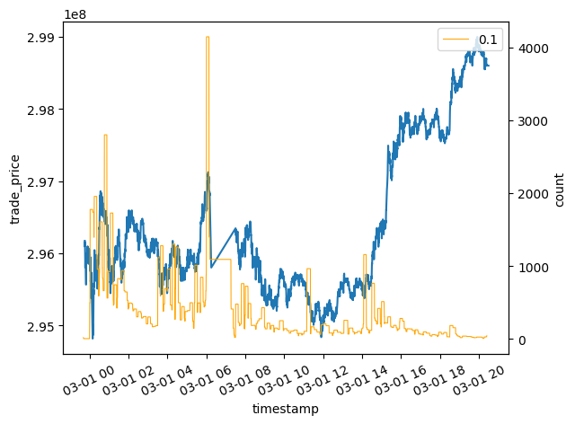

```python
import seaborn as sns
import matplotlib.pyplot as plt
lessthan1sec = pl.col("min_time") < pl.lit(1000).cast(pl.Duration("ms"))
eventcreated = pl.col("event") == "Created"
def cell(df2filter, mintimedf_filter):

    trunc = "15s"
    tscol=pl.col("timestamp").dt.truncate(trunc)
    _df = e_df.group_by(tscol).agg([pl.col("trade_price").mean()])

    ax = sns.lineplot(y=_df["trade_price"], x=_df["timestamp"])
    def func(s): return pl.col(s)
    def unnest_struct(s): return pl.col("order_id").struct.field(s).alias(s)

    joinon = [func("order_id"), func("order_book_id"), func("side")]
    unnest_struct_col = [unnest_struct("order_id"), unnest_struct("order_book_id"), unnest_struct("side")]
    _df = df2.filter(df2filter)
    _df = _df.with_columns(unnest_struct_col).join(order_df.filter(mintimedf_filter), on=joinon)
    _df = _df.group_by(pl.col("timestamp").dt.truncate(trunc)).count().sort("timestamp")

    ax2 = sns.lineplot(y=_df["count"].rolling_max(4*8), x=_df["timestamp"], ax=plt.twinx(), color="orange", size=0.1)
    for i in ax2.get_xticklabels():
        i.set_rotation(25)
    for i in ax.get_xticklabels():
        i.set_rotation(25)


cell(eventcreated, lessthan1sec)
```

### 3.2 Number of `observed maker order *modification*` of orders whose smallest time between `trader initiated event` is less than 1 second

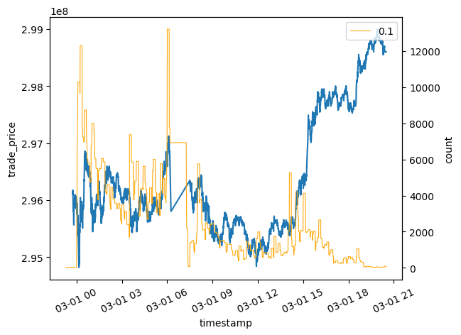

```python
lessthan1sec = pl.col("min_time") < pl.lit(1000).cast(pl.Duration("ms"))
eventcreated = pl.col("event") == "Modify"

cell(eventcreated, lessthan1sec)
```

### 3.3 Number of `observed maker order *creation*` of orders whose smallest time between `trader initiated event` is greather than 30 seconds

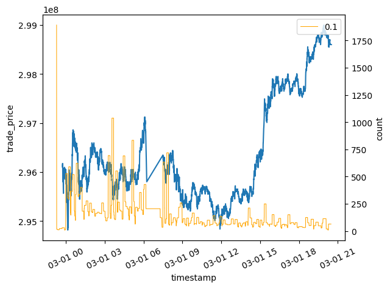

```python
lessthan1sec = (pl.col("min_time") > pl.lit(30_000).cast(pl.Duration("ms")))&(pl.col("min_time") > pl.lit(30000).cast(pl.Duration("ms")))
eventcreated = pl.col("event") == "Created"

cell(eventcreated, lessthan1sec)
```

### 3.4 Number of `observed maker order *modification*` of orders who were *modified* more than *5 times* durting the trading session.

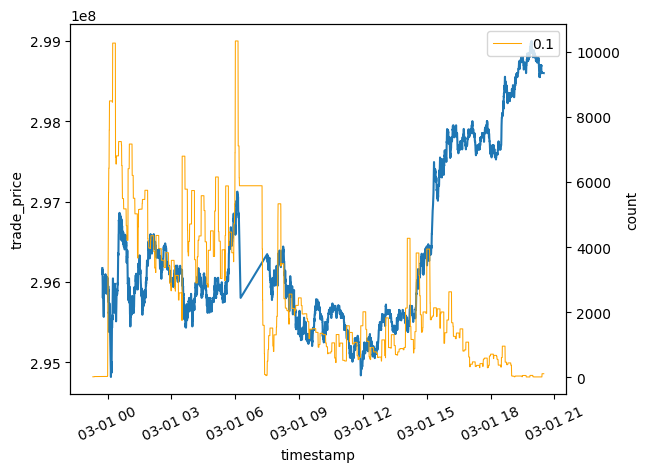

```python
is_del = pl.col("modify_count") > 5
eventcreated = pl.col("event") == "Modify"

cell(eventcreated, is_del)
```

### 3.5 Number of `observed maker order *creation*` of orders who were `deleted` before the end of trading session.

Majority of orders are orders deleted before it was removed before it was fully matched with an order book

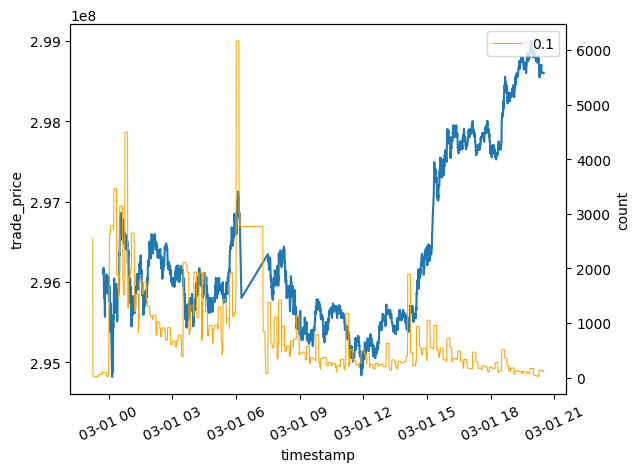

```python
is_del = pl.col("is_deleted")
eventcreated = pl.col("event") == "Created"

cell(eventcreated, is_del)
```

```python
def cell(df2: pl.LazyFrame):
    df3 = product_info_df.lazy().filter(pl.col("symbol").str.contains(
        "NK225")).select("order_book_id", "symbol")
    df2 = df2.with_columns(pl.col("order_id").struct.field("order_book_id").alias(
        "order_book_id")).join(df3.lazy(), on="order_book_id", how="inner")
    df2 = df2.select(pl.exclude("order_book_id"))
    df2 = df2.collect()
    return df2


df2 = cell(df2.lazy())
```

```python
def cell():
    colts=pl.col("timestamp").sort().diff()
    iter = [
        pl.col("timestamp").min().alias("created_on"),
        colts.min().alias("min"),
        colts.max().alias('max'),
        colts.count().alias("count"),
        pl.col("event").filter(pl.col("event") == "Modify").count().alias("modify"),
    ]
    df = pl.DataFrame()
    for i in iter:
        _df=df2.lazy().group_by(pl.col("order_id")).agg([i])
        func = lambda s: pl.col("order_id").struct.field(s)
        schema = [func("order_id"), func("order_book_id"), func("side")]
        if df.height:
            _df2=_df.sort(schema).select(pl.exclude("order_id")).collect()
            df=df.sort(schema).hstack(_df2, in_place =True)
        else:
            df = _df.sort(schema).collect()

    return df

df3=cell()
df3
```

shape: (9_323_874, 6)

| order_id struct[3] | created_on datetime[μs] | min duration[μs] | max duration[μs] | count u32 | modify u32 |
| --- | --- | --- | --- | --- | --- |
| {"Buy",7191680986344451283,141099508} | 2021-02-28 21:07:50.931282 | null | null | 1 | 0 |
| {"Buy",7191680986344452353,141033972} | 2021-02-28 21:07:50.931282 | null | null | 1 | 0 |
| {"Buy",7191680986344462060,140837364} | 2021-02-28 21:07:50.931282 | null | null | 1 | 0 |
| {"Buy",7191680986344469723,140771828} | 2021-02-28 21:07:50.931282 | null | null | 1 | 0 |
| {"Buy",7191680986344473992,140706292} | 2021-02-28 21:07:50.931282 | null | null | 1 | 0 |
| {"Buy",7191680986344478517,140640756} | 2021-02-28 21:07:50.931282 | null | null | 1 | 0 |
| {"Buy",7191680986344482094,140575220} | 2021-02-28 21:07:50.931282 | null | null | 1 | 0 |
| {"Buy",7191680986344483411,140509684} | 2021-02-28 21:07:50.931282 | null | null | 1 | 0 |
| {"Buy",7191680986344488974,140444148} | 2021-02-28 21:07:50.931282 | null | null | 1 | 0 |
| {"Buy",7191680986344491275,140378612} | 2021-02-28 21:07:50.931282 | null | null | 1 | 0 |
| {"Buy",7191680986344495193,140313076} | 2021-02-28 21:07:50.931282 | null | null | 1 | 0 |
| {"Buy",7191680986344496787,140247540} | 2021-02-28 21:07:50.931282 | null | null | 1 | 0 |
| … | … | … | … | … | … |
| {"Buy",7396717914718470994,104137204} | 2021-03-01 20:29:59.962684 | null | null | 1 | 0 |
| {"Buy",7396717914718470995,239469044} | 2021-03-01 20:29:59.962813 | null | null | 1 | 0 |
| {"Sell",7396717914718470996,52888052} | 2021-03-01 20:29:59.962854 | 101461µs | 101461µs | 2 | 0 |
| {"Sell",7396717914718470997,158794228} | 2021-03-01 20:29:59.962908 | null | null | 1 | 0 |
| {"Sell",7396717914718470998,231145972} | 2021-03-01 20:29:59.962954 | null | null | 1 | 0 |
| {"Buy",7396717914718471003,21758452} | 2021-03-01 20:30:00.254932 | 10m 758443µs | 10m 758443µs | 2 | 0 |
| {"Buy",7396717914718471004,33817076} | 2021-03-01 20:30:00.254968 | 754165µs | 754165µs | 2 | 0 |
| {"Buy",7396717914718471005,297337332} | 2021-03-01 20:30:00.255009 | 756683µs | 756683µs | 2 | 0 |
| {"Sell",7396717914718471006,98238964} | 2021-03-01 20:30:00.255046 | 10m 758329µs | 10m 758329µs | 2 | 0 |
| {"Buy",7396717914718471007,258605556} | 2021-03-01 20:30:00.255277 | 753782µs | 753782µs | 2 | 0 |
| {"Sell",7396717914718471016,54723060} | 2021-03-01 20:30:00.992569 | null | null | 1 | 0 |
| {"Sell",7396717914718471017,33751540} | 2021-03-01 20:30:00.992613 | null | null | 1 | 0 |

```python
def cell():
    stack = []
    for i in range(1, 21):
        t=df3.sort("min", descending=True)["min"].quantile(i/20)
        stack.append({"len": df3.filter(pl.col("min") < t).height, "t": t, "quantile": i/20})

    return pl.from_dicts(stack).with_columns(pl.col("t").diff(1).alias("diff"))

cell()
```

shape: (20, 4)

| len i64 | t duration[μs] | quantile f64 | diff duration[μs] |
| --- | --- | --- | --- |
| 465023 | 16646µs | 0.05 | null |
| 930066 | 73803µs | 0.1 | 57157µs |
| 1395106 | 192985µs | 0.15 | 119182µs |
| 1860141 | 360900µs | 0.2 | 167915µs |
| 2325177 | 578225µs | 0.25 | 217325µs |
| 2790212 | 885931µs | 0.3 | 307706µs |
| 3255249 | 1s 308126µs | 0.35 | 422195µs |
| 3720284 | 1s 944430µs | 0.4 | 636304µs |
| 4185320 | 2s 788909µs | 0.45 | 844479µs |
| 4650356 | 3s 996089µs | 0.5 | 1s 207180µs |
| 5115390 | 5s 637522µs | 0.55 | 1s 641433µs |
| 5580426 | 8s 11847µs | 0.6 | 2s 374325µs |
| 6045461 | 11s 264325µs | 0.65 | 3s 252478µs |
| 6510498 | 15s 901303µs | 0.7 | 4s 636978µs |
| 6975533 | 23s 13557µs | 0.75 | 7s 112254µs |
| 7440569 | 34s 631905µs | 0.8 | 11s 618348µs |
| 7905604 | 55s 857813µs | 0.85 | 21s 225908µs |
| 8370640 | 1m 43s 762620µs | 0.9 | 47s 904807µs |
| 8835675 | 4m 25s 537062µs | 0.95 | 2m 41s 774442µs |
| 9300711 | 23h 20m 58s 367782µs | 1.0 | 23h 16m 32s 830720µs |

```python
def cell():
    stack = []
    r = list(range(0, 10))
    r.append(25)
    r.append(50)
    r.append(100)
    for i in r:
        stack.append({"len": df3.filter(pl.col("modify") == i).height, "t": i})
        if stack[-1]["len"] == 0:
            break

    return pl.from_dicts(stack).with_columns(pl.col("len"))

cell()
```

shape: (13, 2)

| len i64 | t i64 |
| --- | --- |
| 8271545 | 0 |
| 541099 | 1 |
| 146303 | 2 |
| 74361 | 3 |
| 44502 | 4 |
| 31866 | 5 |
| 23316 | 6 |
| 19017 | 7 |
| 15810 | 8 |
| 13407 | 9 |
| 2732 | 25 |
| 631 | 50 |
| 105 | 100 |

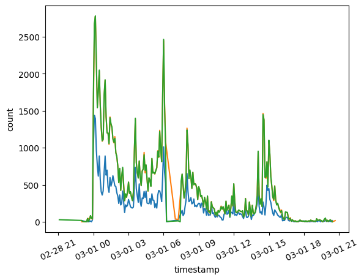

```python
import seaborn as sns
def main(filSymboL: str):
    df4=df2.with_columns(pl.col("timestamp").cast(pl.Datetime)).with_columns(pl.col(["event", "symbol"]).cast(pl.Categorical))
    _df4=df4.filter(pl.col("symbol") == filSymboL).filter(pl.col("event") == "Modify").group_by(pl.col("timestamp").dt.truncate("5m")).count().sort("timestamp")
    ax=sns.lineplot(data=_df4, x="timestamp", y="count")
    _df4=df4.filter(pl.col("symbol") == filSymboL).filter(pl.col("event") == "Deleted").group_by(pl.col("timestamp").dt.truncate("5m")).count().sort("timestamp")
    ax=sns.lineplot(data=_df4, x="timestamp", y="count")
    _df4=df4.filter(pl.col("symbol") == filSymboL).filter(pl.col("event") == "Created").group_by(pl.col("timestamp").dt.truncate("5m")).count().sort("timestamp")
    ax=sns.lineplot(data=_df4, x="timestamp", y="count")
    for i in ax.get_xticklabels():
        i.set_rotation(25)

main("CAL_NK225_210312_29500")
```

```python
import seaborn as sns
symbol="FUT_NK225M_2106"
df4 = df3
_df42=df4.filter(pl.col("symbol") == symbol).filter(pl.col("event") == "Modify").group_by(pl.col("timestamp").dt.truncate("5m")).count().sort("timestamp")
ax=sns.lineplot(_df42, y="count", x="timestamp")
_df42=df4.filter(pl.col("symbol") == symbol).filter(pl.col("event") == "Created").group_by(pl.col("timestamp").dt.truncate("5m")).count().sort("timestamp")
ax=sns.lineplot(_df42, y="count", x="timestamp")
_df42=df4.filter(pl.col("symbol") == symbol).filter(pl.col("event") == "Deleted").group_by(pl.col("timestamp").dt.truncate("5m")).count().sort("timestamp")
ax=sns.lineplot(_df42, y="count", x="timestamp")
for i in ax.get_xticklabels():
    i.set_rotation(25)
```

[output not shown]